# STAT331 Final Report

Zeheng Zhang

8/7/2020

- Student ID: 20745148

## 1.Introduction

In the course STAT331 we have learned different techniques to model the relationship between a response variable and several explanatory variables via Multiple Linear Regression Model(MLRM). In this report, relationships between real estate price (the response variable) and several other factors (the explanatory variables) potentially influencing the price will be analyzed based on the dataset dtrain. The modeling process contains three major steps: preliminary analysis, model selection and model diagnostics.

## 2. Preliminary Analysis

### 2.1 Dataset description

The Dataset contains following variables:

- Price: the response variable we want to predict
- bathrm: number of bathrooms
- hf_bathrm: number of half bathrooms
- heat: heating type  
  Possible values: "Air Exchng" "Elec Base Brd" "Forced Air" "Gravity Furnac" "Hot Water Rad"  
  "Ht Pump" "No Data" "Wall Furnace" "Warm Cool" "Water Base Brd"
- ac: Whether or not air conditioning exists. Possible value: "Y", "N"
- rooms: number of rooms
- bedrm: number of bedrooms
- ayb: the earliest time the main portion of the building was built
- yr_rmdl: year structure was remodelled
- eyb: the year an improvement was built more recent than actual year built
- stories: number of stories in primary dwelling
- saledate: date of most recent sale
- gba: gross building area in square feet
- style: style type.  
  Possible values: "1 Story" "1.5 Story Fin" "1.5 Story Unfin" "2 Story" "2.5 Story Fin" "2.5 Story Unfin" "3 Story" "4 Story" "Bi-Level" "Default" "Split Foyer" "Split Level"
- grade: Grade of quality.  
  Possible values: "Above Average" "Average" "Fair Quality" "Good Quality" "Low Quality" "Superior" "Very Good"
- extwall: exterior wall type  
  Possible values: "Adobe" "Aluminum" "Brick Veneer" "Brick/Siding" "Brick/Stone" "Brick/Stucco" "Common Brick" "Concrete" "Concrete Block" "Face Brick" "Hardboard" "Metal Siding" "Shingle" "Stone" "Stone Veneer" "Stone/Siding" "Stone/Stucco" "Stucco" "Stucco Block" "Vinyl Siding" "Wood Siding"
- kitchens: number of kitchens
- fireplaces: number of fireplaces
- landarea: land area of property in square feet

### 2.2 Basic data checking

The 18 explanatory variables originally consist of 13 numerical variables and 5 categorical variables. (The saledate variable is of the data type character, for example "2013-02-20"). In common sense, saledate of a real estate often has quantitative relationship with its price. In order to study this relationship, we convert saledate to a numerical variable:

```r
dtrain$saledate <- as.numeric(as.Date(dtrain$saledate)) # Counting days from 0000-00-00
```

By checking the dataset, we found that there are missing values in the columns yr_rmdl and stories, so we replace the missing values with their column mean. Since only a small number of values are missing, this will not largely decrease accuracy of the model.

```r
dtrain$yr_rmdl[is.na(dtrain$yr_rmdl)] <- average_yr_rmdl
dtrain$stories[is.na(dtrain$stories)] <- average_stories
```

### 2.3 y-x relationship analysis

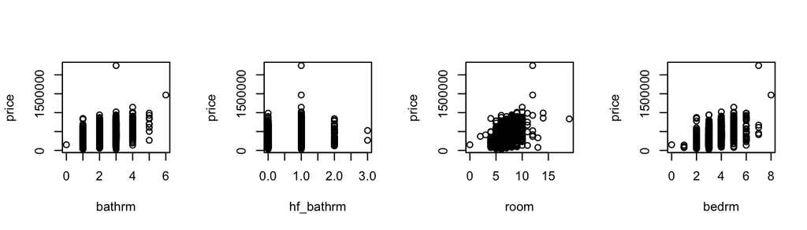

Y-X pair plots

In Figure 1 we see pair plots between price and room number variables (bathrm, hf_bathrm, rooms, bedrm). Positive correlations can be seen in the plots price~bathrm, price~rooms and price~bedrm.

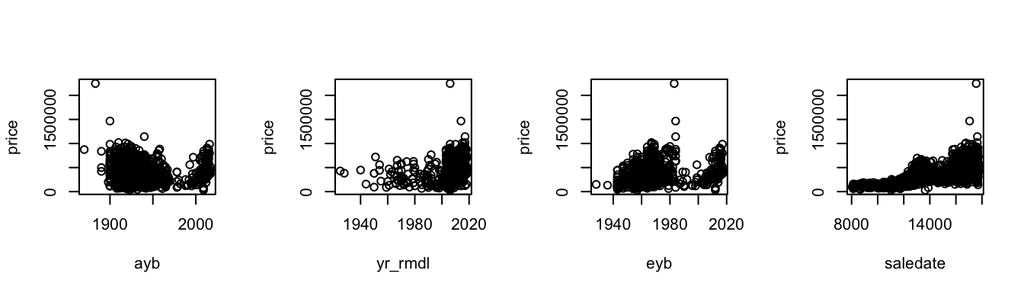

Y-X pair plots

In Figure 2 we see pair plots between price and time variables (ayb, yr_rmdl, eyb, saledate). Positive correlations can be seen in the plots price~yr_rmdl and price~saledate.

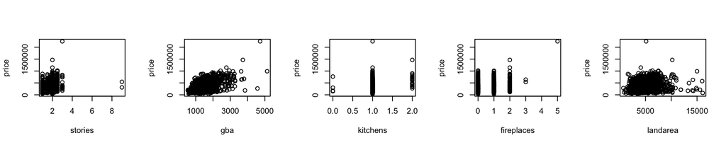

Y-X pair plots

In Figure 3 we see pair plots between price and other variables (stories,gba,kitchens,fireplaces,landarea). Positive correlations can be seen in the plots price~stories and price~gba.

### 2.4 x-x relationship analysis

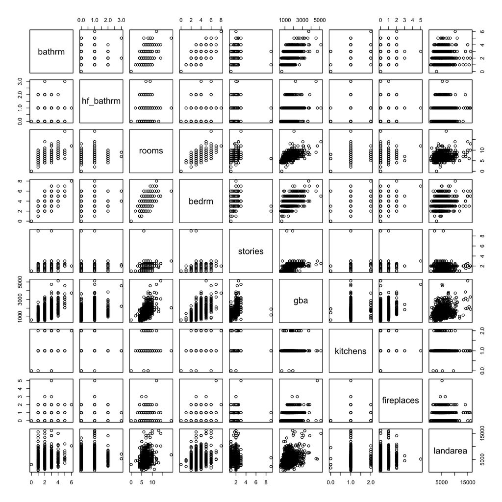

non-time variables pair plots

In Figure 4, positive correlation between non-time variables can be seen in the plots bathrm~rm, bathrm~bedrm, bathrm~stories, bathrm~gba, rooms~bedrm, rooms~gba, bedrm~stories and bedrm~gba

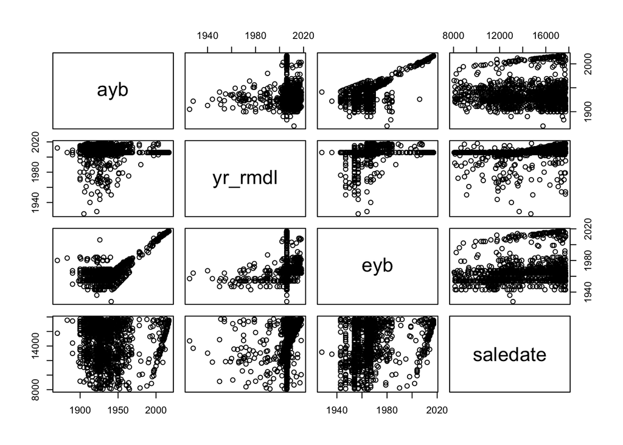

Time variables pair plots

In Figure 5, positive correlation between can be seen in the plot ayb~eyb

## 3. Model Selection

In order to determine the best fitted model, we need to compare several different models. We use different model generating techniques to maximize our chance to find the best model.

### 3.1 Building Model based on plots

```r
model1 <- lm(price~bathrm + rooms + bedrm + yr_rmdl + saledate + gba, data = dtrain)
```

After building the basic model, we now try to add categorical variables to the model and see if they improves the model.

```r
addterm(model1, scope = fullcategoricalmodel, test = "F")
```

|  | Df | Sum of Sq | RSS | AIC | F Value | Pr(F) |
| --- | --- | --- | --- | --- | --- | --- |
|  | NA | NA | 1.984887e+13 | 30565.11 | NA | NA |
| heat | 9 | 3.151280e+11 | 1.953374e+13 | 30562.25 | 2.306947e+00 | 1.428489e-02 |
| ac | 1 | 1.821499e+04 | 1.984887e+13 | 30567.11 | 1.188401e-06 | 9.991304e-01 |
| style | 11 | 9.307812e+11 | 1.891809e+13 | 30524.53 | 5.747525e+00 | 4.049857e-09 |
| grade | 6 | 3.377095e+12 | 1.647177e+13 | 30334.10 | 4.407998e+01 | 3.517627e-49 |
| extwall | 20 | 1.681854e+12 | 1.816701e+13 | 30489.74 | 5.906437e+00 | 4.020176e-15 |

After running F-test on the model obtained by adding the categorical variable grade into our basic model, we found that the p-value is extremely, which implies that grade is an important variable. Then we repeat this process to try to add other categorical variables into our model until the rest categorical variables are not important. After this forward selection process, the important categorical variables added into our model are grade, extwall and style. Hence our basic model becomes:

```r
model1 <- lm(price~bathrm + rooms + bedrm + yr_rmdl + saledate + gba + grade + extwall
             + style, data = dtrain)
```

### 3.2 Building model using automated methods

Now we try to automatically generate a different models using stepwise regression by AIC (Criteria used to compare models). Stepwise regression is a combined greedy algorithm that starts each loop with a forward selection like how we add categorical variables in 3.1 to add an important variable. Then it checks all predictors of their AIC to drop the least significant predictor until no predictors can be added or removed.

```r
nullmodel<-lm(price~1, data=dtrain)
fullmodel<-lm(price~., data=dtrain)
stepwise_model<-step(nullmodel, scope=list(upper=fullmodel), direction = "both")
```

```r
stepwise_model$call
```

```
## lm(formula = price ~ saledate + gba + grade + ayb + bathrm +
##     fireplaces + extwall + eyb + hf_bathrm + rooms + landarea +
##     kitchens, data = dtrain)
```

The predictors selected by stepwise regression are:  
saledate, gba, grade, ayb, bathrm, fireplaces, extwall, eyb, hf_bathrm, rooms, landarea, kitchens

### 3.3 Model comparison

Now we compare the two models using different criteria to choose our final model

```r
summary(model1)
summary(stepwise_model)
```

```r
AIC(model1)
```

```
## [1] 33952.43
```

```r
AIC(stepwise_model)
```

```
## [1] 33803.25
```

model1 has greater AIC than stepwise_model (model with lower AIC implies is better fitted)

```r
BIC(model1)
```

```
## [1] 34185.19
```

```r
BIC(stepwise_model)
```

```
## [1] 33999.8
```

model1 has greater BIC than stepwise_model (model with lower BIC implies is better fitted)  
Based on the comparison, stepwise_model is better fitted than model1, so we choose stepwise_model to be our final model.

## 4.Model Diagnostics

## 4.1 Assumptions Checking

We need to check four assumptions of multiple linear regression model to assure the correctness of the model.

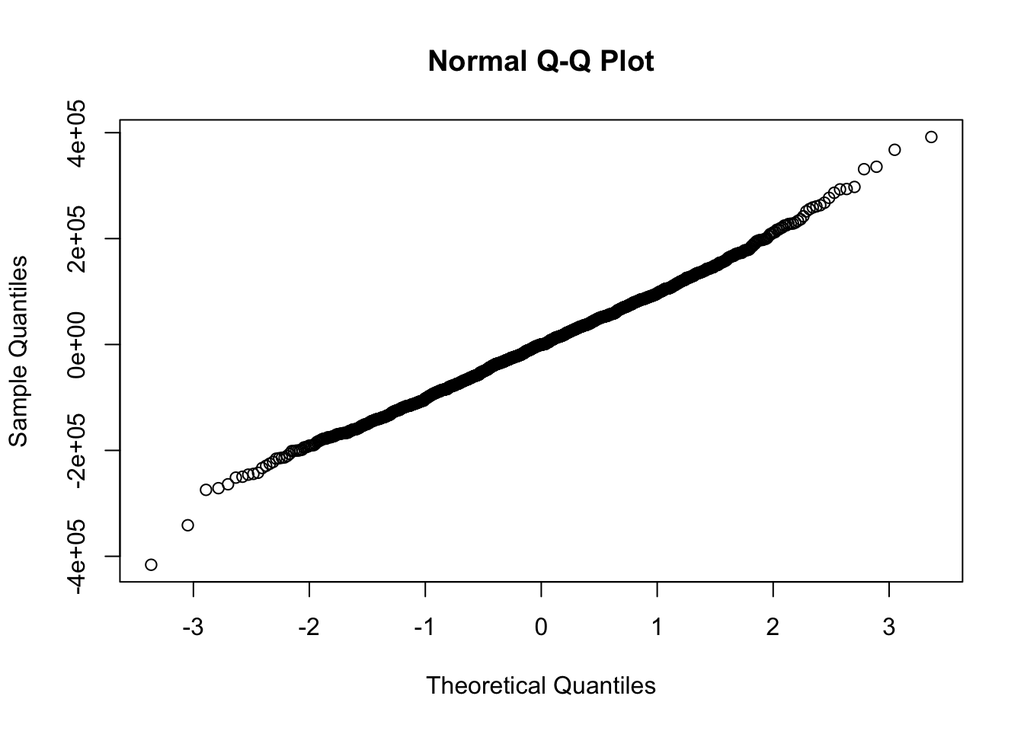

Q-Q plot

```r
qqnorm(residuals(stepwise_model))
```

In figure 6, the pattern implies that the normality assumption is satisfied.

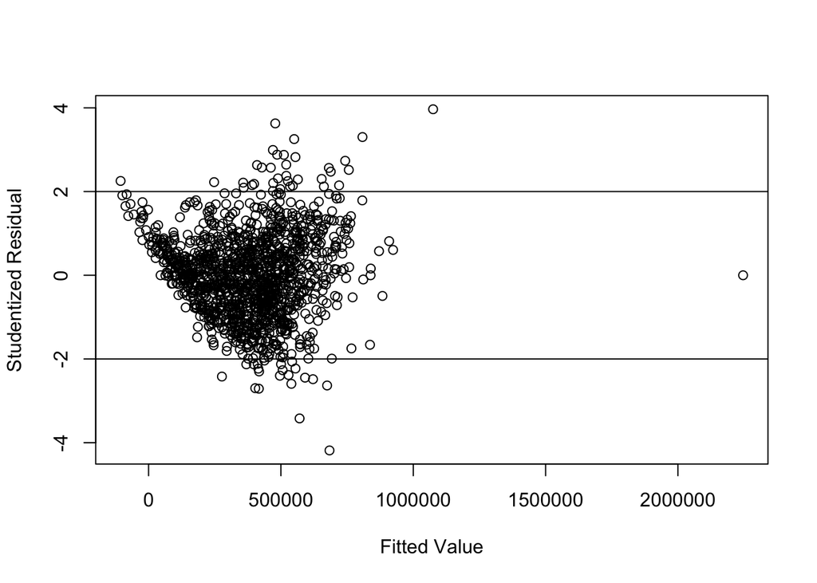

Studentized residuals versus fitted values

```r
plot(fitted.values(stepwise_model), studresid, ylab="Studentized Residual", xlab = "Fitted Value")
abline(h=2)
abline(h=-2)
```

In figure 7, the points are distributed around 0, so mean of zero is satisfied. To satisfy the constant variance assumption, the points should lie within a horizontal band, yet the points in the plot exhibit a decreasing pattern at left, so the constant variance assumption is not satisfied.

## 4.2 Transformation

In order to improve the model, we apply variance stabilizing transformation to the model. To decide what transformation to be adopted, we use the built-in boxcox function in R to check the model:

```r
bc<-boxcox(stepwise_model, lambda=seq(-1,1,1/20))
```

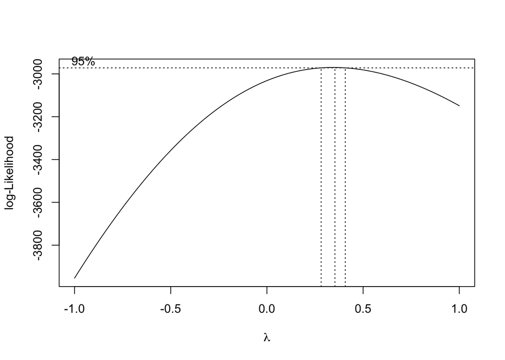

```r
bc$x[which.max(bc$y)]
```

```
## [1] 0.3535354
```

By Box-Cox transformation, we transform the response variable, price to be price^0.3535354:

```r
stepwise_model<-lm(price^0.3535354 ~ saledate + gba + grade + ayb + bathrm +
                     fireplaces + extwall + eyb + hf_bathrm + rooms + landarea +
                     kitchens, data = dtrain)
```

## 4.3 Assumptions Checking 2

To make sure that the transformation is effective, we check the assumptions again.

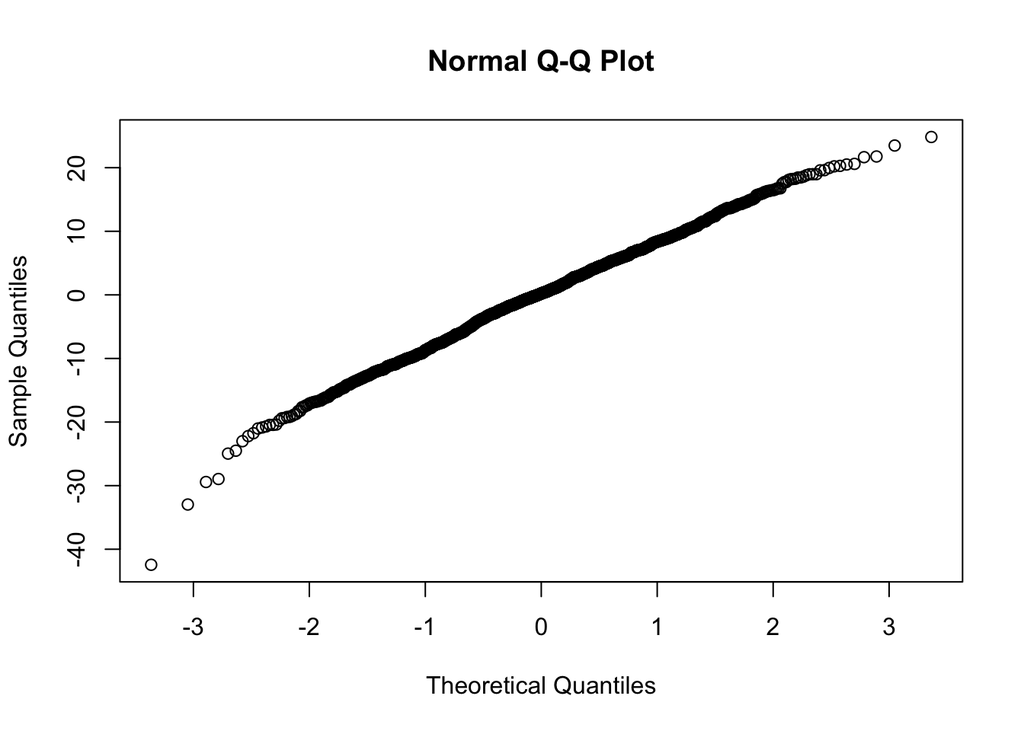

Q-Q plot

```r
qqnorm(residuals(stepwise_model))
```

In figure 8, the pattern implies that the normality assumption is satisfied.

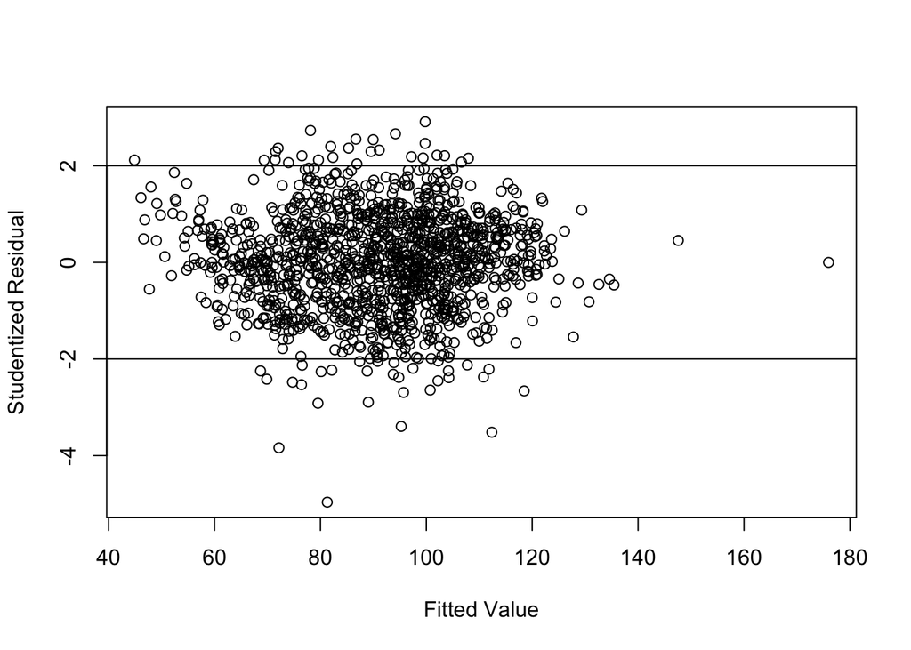

Studentized residuals versus fitted values

```r
plot(fitted.values(stepwise_model), studresid, ylab="Studentized Residual", xlab = "Fitted Value")
abline(h=2)
abline(h=-2)
```

In figure 9, the points are distributed around 0, so mean of zero is satisfied. The points lie within a horizontal band around zero, no special pattern is exhibited and approximately 95% of the points lie within (-2,2), so the constant variance assumption is satisfied.

## 4.4. Data Checking

In order to improve the model, we check any extreme observations in the dataset by searching for outliers. An outlier is a particular observation with unusual value in y or x;

### 4.4.1 Outliers in Y-direction

By the definition of outlier in y, any observation i with studentized residual |$d_i$| > 2.5 is a outlier in y.  
All Outliers in y with their studentized residuals in the dataset are:

```
##         3         5       127       147       207       429       436       461
## -2.893922  2.909894  2.539685 -2.643527  2.660775 -3.838730  2.549871 -2.532214
##       471       608       752      1076      1128      1223      1274
## -3.516491 -2.660775  2.729157 -2.692522 -2.915997 -3.395937 -4.963549
```

### 4.4.2 Outliers in X-direction

```
##          2         32         34        105        112        118        121
## 1.00000000 0.26971037 0.07019938 0.11057391 0.06969682 0.51029076 0.27305481
##        131        139        141        143        151        153        166
## 0.20357985 0.21760185 0.05690060 0.06879772 0.33657660 0.33764695 0.11489585
##        179        191        192        198        201        207        217
## 0.33667906 0.12538241 0.20353750 0.12331919 0.09913894 0.50429992 0.09427660
##        223        234        244        267        290        298        303
## 0.07083916 0.10586764 0.08282762 0.20617747 0.10292386 0.08370280 0.10859751
##        304        319        324        325        326        327        387
## 0.20453659 0.10491361 0.08508899 0.08447988 0.08406691 0.08343972 0.25409703
##        400        430        437        445        471        490        507
## 0.07015956 0.09729540 0.06758587 0.27081389 0.05943645 0.25644541 0.26196764
##        517        536        565        576        581        599        601
## 0.08157490 0.07544405 0.20753687 0.07804039 0.07185059 0.20789358 0.13084261
##        608        618        625        634        643        651        674
## 0.50429992 0.20341702 0.08134101 0.10078058 0.07216308 0.10061588 0.07611089
##        687        707        710        711        715        716        723
## 0.07981400 0.20825967 0.06986181 0.06820810 0.09717242 0.08413400 0.25528923
##        732        737        741        749        755        756        761
## 0.08232536 0.07624233 0.25602086 0.10436928 0.07183866 0.11043810 0.20240731
##        780        783        793        799        820        838        885
## 0.05976741 0.08255449 0.08343363 0.08480178 0.22490787 0.09667645 0.26478659
##        912        943        945        966        983        988       1015
## 0.10542285 0.10706184 0.10873385 1.00000000 0.25399518 1.00000000 0.11078659
##       1028       1054       1084       1100       1110       1123       1132
## 0.20993581 0.10488485 0.20659156 0.07608645 0.25449528 0.51029076 0.25635085
##       1150       1174       1182       1183       1187       1201       1204
## 0.20554503 0.07981664 0.07029109 0.07441655 0.08170540 0.08338304 0.07053063
##       1205       1206       1210       1231       1232       1238       1241
## 0.12368088 0.07844707 0.20163747 0.06760010 0.06936294 0.07149707 0.07297167
##       1261       1264       1281       1282       1289       1298
## 0.05906357 1.00000000 0.07145837 0.06945596 0.07412364 0.07883169
```

Since there is no evidence for recording errors, these outliers are retained in the dataset.

## 5. Model intepretation

The final model is $price^{0.3535354} \sim \beta_0 + \beta_1*saleyear + \beta_2*gba + \beta_3*I_{grade=Average} + \beta_4*I_{grade=Fair Quality} + \beta_5*I_{grade=Good Quality} + \beta_6*I_{grade=Low Quality} + \beta_7*I_{grade=Superior} + \beta_8*I_{grade=Very Good} + \beta_9*ayb + \beta_{10}*bathrm + \beta_{11}*fireplaces + \beta_{12}*I_{extwall=Aluminum} + \beta_{13}*I_{extwall=Brick Veneer} + \beta_{14}*I_{extwall=Brick/Siding} + \beta_{15}*I_{extwall=Brick/Stone} + \beta_{16}*I_{Brick/Stucco} + \beta_{17}*I_{extwall=Common Brick} + \beta_{18}*I_{extwall=Concrete} + \beta_{19}*I_{extwall=Concrete Block} + \beta_{20}*I_{extwall=Face Brick} + \beta_{21}*I_{extwall=Hardboard} + \beta_{22}*I_{extwall=Metal Siding} + \beta_{23}*I_{extwall=Shingle} + \beta_{24}*I_{extwall=Stoneeyb} + \beta_{25}*I_{extwall=Stone Veneer} + \beta_{26}*I_{extwall=Stone/Siding} + \beta_{27}*I_{extwall=Stone/Stucco} + \beta_{28}*I_{extwall=Stucco} + \beta_{29}*I_{extwall=Stucco Block} \beta_{30}*I_{extwall=Vinyl Siding} + \beta_{31}*I_{extwallWood Siding} + \beta_{32}*eyb + \beta_{33}*hf\_bathrm + \beta_{34}*rooms + \beta_{35}*landarea + \beta_{36}*kitchens + \epsilon$,  
where $\epsilon \sim$ i.i.d. N(0,$\sigma^2$)

The numerical explanatory variable included in this model are: saledate, gba, ayb, bathrm, fireplaces, eyb, hf_bathrm, rooms, landarea, kitchens  
The categorical explanatory variables included in this model are: grade, extwall

The estimated coefficients are:

```
##           (Intercept)              saledate                   gba
##         -2.983342e+01          4.684998e-03          4.493645e-03
##          gradeAverage     gradeFair Quality     gradeGood Quality
##         -4.536327e+00         -9.824757e+00          5.576925e+00
##      gradeLow Quality         gradeSuperior        gradeVery Good
##          7.971888e+00          2.257197e+01          5.902451e+00
##                   ayb                bathrm            fireplaces
##         -1.727904e-01          3.051268e+00          3.211363e+00
##       extwallAluminum   extwallBrick Veneer   extwallBrick/Siding
##         -9.581780e-02         -1.014890e-01         -4.964417e+00
##    extwallBrick/Stone   extwallBrick/Stucco   extwallCommon Brick
##         -5.448808e+00         -6.227886e+00         -4.631646e-01
##       extwallConcrete extwallConcrete Block     extwallFace Brick
##         -9.517225e+00          2.722630e+00          1.867623e+00
##      extwallHardboard   extwallMetal Siding        extwallShingle
##          5.200223e+00          1.009506e+01         -1.469372e+00
##          extwallStone   extwallStone Veneer   extwallStone/Siding
##         -2.379741e+00          4.722105e-01         -2.360154e+00
##   extwallStone/Stucco         extwallStucco   extwallStucco Block
##          2.714759e+00         -1.992882e+00          1.030487e+00
##   extwallVinyl Siding    extwallWood Siding                   eyb
##         -3.117937e+00         -8.710620e-02          1.867106e-01
##             hf_bathrm                 rooms              landarea
##          1.720440e+00          5.376010e-01          2.924026e-04
##              kitchens
##          2.385283e+00
```

The intercept $\beta_0$ is the average response when all numerical predictors are equal to 0 and all categorical predictors are equal to their default value ("Above Average" for grade and "Adobe" for extwall)

$\epsilon$ is the random error. It represent everything the model does not have into account such as factors that may interfere the price and measuring inaccuracies.